# Risk Factor Analysis

## Outcome Variable

**Outcome Variable:** haz

## Predictor Variables

**Intervention Variable:** birthwt

**Adjustment Set:**

- arm
- sex
- W_mage
- meducyrs
- feducyrs
- vagbrth
- single
- brthmon
- W_parity
- delta_W_mage
- delta_meducyrs
- delta_feducyrs
- delta_vagbrth
- delta_single
- delta_brthmon
- delta_W_parity

## Stratifying Variables

The analysis was stratified on these variable(s):

- agecat
- studyid
- country

## Data Summary

| agecat | studyid | country | birthwt | n_cell | n | outcome_variable |
| --- | --- | --- | --- | --- | --- | --- |
| Birth | CMC-V-BCS-2002 | INDIA | Normal or high birthweight | 81 | 92 | haz |
| Birth | CMC-V-BCS-2002 | INDIA | Low birthweight | 11 | 92 | haz |
| Birth | CMIN | BANGLADESH | Normal or high birthweight | 14 | 26 | haz |
| Birth | CMIN | BANGLADESH | Low birthweight | 12 | 26 | haz |
| Birth | COHORTS | GUATEMALA | Normal or high birthweight | 717 | 784 | haz |
| Birth | COHORTS | GUATEMALA | Low birthweight | 67 | 784 | haz |
| Birth | COHORTS | INDIA | Normal or high birthweight | 5268 | 6638 | haz |
| Birth | COHORTS | INDIA | Low birthweight | 1370 | 6638 | haz |
| Birth | COHORTS | PHILIPPINES | Normal or high birthweight | 2709 | 3004 | haz |
| Birth | COHORTS | PHILIPPINES | Low birthweight | 295 | 3004 | haz |
| Birth | CONTENT | PERU | Normal or high birthweight | 2 | 2 | haz |
| Birth | CONTENT | PERU | Low birthweight | 0 | 2 | haz |
| Birth | EE | PAKISTAN | Normal or high birthweight | 160 | 240 | haz |
| Birth | EE | PAKISTAN | Low birthweight | 80 | 240 | haz |
| Birth | GMS-Nepal | NEPAL | Normal or high birthweight | 476 | 696 | haz |
| Birth | GMS-Nepal | NEPAL | Low birthweight | 220 | 696 | haz |
| Birth | IRC | INDIA | Normal or high birthweight | 317 | 383 | haz |
| Birth | IRC | INDIA | Low birthweight | 66 | 383 | haz |
| Birth | JiVitA-3 | BANGLADESH | Normal or high birthweight | 12858 | 22454 | haz |
| Birth | JiVitA-3 | BANGLADESH | Low birthweight | 9596 | 22454 | haz |
| Birth | JiVitA-4 | BANGLADESH | Normal or high birthweight | 1799 | 2823 | haz |
| Birth | JiVitA-4 | BANGLADESH | Low birthweight | 1024 | 2823 | haz |
| Birth | Keneba | GAMBIA | Normal or high birthweight | 1308 | 1529 | haz |
| Birth | Keneba | GAMBIA | Low birthweight | 221 | 1529 | haz |
| Birth | MAL-ED | BANGLADESH | Normal or high birthweight | 177 | 231 | haz |
| Birth | MAL-ED | BANGLADESH | Low birthweight | 54 | 231 | haz |
| Birth | MAL-ED | BRAZIL | Normal or high birthweight | 61 | 65 | haz |
| Birth | MAL-ED | BRAZIL | Low birthweight | 4 | 65 | haz |
| Birth | MAL-ED | INDIA | Normal or high birthweight | 39 | 47 | haz |
| Birth | MAL-ED | INDIA | Low birthweight | 8 | 47 | haz |

[output cut: 126 more lines]

The following strata were considered:

- agecat: 24 months, studyid: CMC-V-BCS-2002, country: INDIA
- agecat: 24 months, studyid: CMIN, country: BANGLADESH
- agecat: 24 months, studyid: COHORTS, country: GUATEMALA
- agecat: 24 months, studyid: COHORTS, country: INDIA
- agecat: 24 months, studyid: COHORTS, country: PHILIPPINES
- agecat: 24 months, studyid: CONTENT, country: PERU
- agecat: 24 months, studyid: EE, country: PAKISTAN
- agecat: 24 months, studyid: GMS-Nepal, country: NEPAL
- agecat: 24 months, studyid: IRC, country: INDIA
- agecat: 24 months, studyid: JiVitA-3, country: BANGLADESH
- agecat: 24 months, studyid: JiVitA-4, country: BANGLADESH
- agecat: 24 months, studyid: Keneba, country: GAMBIA
- agecat: 24 months, studyid: MAL-ED, country: BANGLADESH
- agecat: 24 months, studyid: MAL-ED, country: BRAZIL
- agecat: 24 months, studyid: MAL-ED, country: INDIA
- agecat: 24 months, studyid: MAL-ED, country: NEPAL
- agecat: 24 months, studyid: MAL-ED, country: PERU
- agecat: 24 months, studyid: MAL-ED, country: SOUTH AFRICA
- agecat: 24 months, studyid: MAL-ED, country: TANZANIA, UNITED REPUBLIC OF
- agecat: 24 months, studyid: NIH-Birth, country: BANGLADESH
- agecat: 24 months, studyid: NIH-Crypto, country: BANGLADESH
- agecat: 24 months, studyid: PROBIT, country: BELARUS
- agecat: 24 months, studyid: PROVIDE, country: BANGLADESH
- agecat: 24 months, studyid: TanzaniaChild2, country: TANZANIA, UNITED REPUBLIC OF
- agecat: 24 months, studyid: ZVITAMBO, country: ZIMBABWE
- agecat: 6 months, studyid: CMC-V-BCS-2002, country: INDIA
- agecat: 6 months, studyid: CMIN, country: BANGLADESH
- agecat: 6 months, studyid: COHORTS, country: GUATEMALA
- agecat: 6 months, studyid: COHORTS, country: INDIA
- agecat: 6 months, studyid: COHORTS, country: PHILIPPINES
- agecat: 6 months, studyid: CONTENT, country: PERU
- agecat: 6 months, studyid: EE, country: PAKISTAN
- agecat: 6 months, studyid: GMS-Nepal, country: NEPAL
- agecat: 6 months, studyid: IRC, country: INDIA
- agecat: 6 months, studyid: JiVitA-3, country: BANGLADESH
- agecat: 6 months, studyid: JiVitA-4, country: BANGLADESH
- agecat: 6 months, studyid: Keneba, country: GAMBIA
- agecat: 6 months, studyid: MAL-ED, country: BANGLADESH
- agecat: 6 months, studyid: MAL-ED, country: BRAZIL
- agecat: 6 months, studyid: MAL-ED, country: INDIA
- agecat: 6 months, studyid: MAL-ED, country: NEPAL
- agecat: 6 months, studyid: MAL-ED, country: PERU
- agecat: 6 months, studyid: MAL-ED, country: SOUTH AFRICA
- agecat: 6 months, studyid: MAL-ED, country: TANZANIA, UNITED REPUBLIC OF
- agecat: 6 months, studyid: NIH-Birth, country: BANGLADESH
- agecat: 6 months, studyid: NIH-Crypto, country: BANGLADESH
- agecat: 6 months, studyid: PROBIT, country: BELARUS
- agecat: 6 months, studyid: PROVIDE, country: BANGLADESH
- agecat: 6 months, studyid: ResPak, country: PAKISTAN
- agecat: 6 months, studyid: SAS-CompFeed, country: INDIA
- agecat: 6 months, studyid: TanzaniaChild2, country: TANZANIA, UNITED REPUBLIC OF
- agecat: 6 months, studyid: ZVITAMBO, country: ZIMBABWE
- agecat: Birth, studyid: CMC-V-BCS-2002, country: INDIA
- agecat: Birth, studyid: CMIN, country: BANGLADESH
- agecat: Birth, studyid: COHORTS, country: GUATEMALA
- agecat: Birth, studyid: COHORTS, country: INDIA
- agecat: Birth, studyid: COHORTS, country: PHILIPPINES
- agecat: Birth, studyid: CONTENT, country: PERU
- agecat: Birth, studyid: EE, country: PAKISTAN
- agecat: Birth, studyid: GMS-Nepal, country: NEPAL
- agecat: Birth, studyid: IRC, country: INDIA
- agecat: Birth, studyid: JiVitA-3, country: BANGLADESH
- agecat: Birth, studyid: JiVitA-4, country: BANGLADESH
- agecat: Birth, studyid: Keneba, country: GAMBIA
- agecat: Birth, studyid: MAL-ED, country: BANGLADESH
- agecat: Birth, studyid: MAL-ED, country: BRAZIL
- agecat: Birth, studyid: MAL-ED, country: INDIA
- agecat: Birth, studyid: MAL-ED, country: NEPAL
- agecat: Birth, studyid: MAL-ED, country: PERU
- agecat: Birth, studyid: MAL-ED, country: SOUTH AFRICA
- agecat: Birth, studyid: MAL-ED, country: TANZANIA, UNITED REPUBLIC OF
- agecat: Birth, studyid: NIH-Birth, country: BANGLADESH
- agecat: Birth, studyid: NIH-Crypto, country: BANGLADESH
- agecat: Birth, studyid: PROBIT, country: BELARUS
- agecat: Birth, studyid: PROVIDE, country: BANGLADESH
- agecat: Birth, studyid: ResPak, country: PAKISTAN
- agecat: Birth, studyid: SAS-CompFeed, country: INDIA
- agecat: Birth, studyid: ZVITAMBO, country: ZIMBABWE

### Dropped Strata

Some strata were dropped due to rare outcomes:

- agecat: Birth, studyid: CONTENT, country: PERU
- agecat: Birth, studyid: MAL-ED, country: BRAZIL
- agecat: Birth, studyid: MAL-ED, country: NEPAL
- agecat: Birth, studyid: PROBIT, country: BELARUS
- agecat: 6 months, studyid: CMIN, country: BANGLADESH
- agecat: 6 months, studyid: CONTENT, country: PERU
- agecat: 6 months, studyid: PROBIT, country: BELARUS
- agecat: 24 months, studyid: CMIN, country: BANGLADESH
- agecat: 24 months, studyid: CONTENT, country: PERU
- agecat: 24 months, studyid: PROBIT, country: BELARUS
- agecat: 24 months, studyid: TanzaniaChild2, country: TANZANIA, UNITED REPUBLIC OF

## Methods Detail

We’re interested in the causal parameters $E[Y_a]$ for all values of $a \in \mathcal{A}$. These parameters represent the mean outcome if, possibly contrary to fact, we intervened to set all units to have $A=a$. Under the randomization and positivity assumptions, these are identified by the statistical parameters $\psi_a=E_W[E_{Y|A,W}(Y|A=a,W)]$. In addition, we’re interested in the mean of $Y$, $E[Y]$ under no intervention (the observed mean). We will estimate these parameters by using SuperLearner to fit the relevant likelihood factors – $E_{Y|A,W}(Y|A=a,W)$ and $p(A=a|W)$, and then updating our likelihood fit using a joint TMLE.

For unadjusted analyses ($W=\{\}$), initial likelihoods were estimated using Lrnr_glm to estimate the simple $E(Y|A)$ and Lrnr_mean to estimate $p(A)$. For adjusted analyses, a small library containing Lrnr_glmnet, Lrnr_xgboost, and Lrnr_mean was used.

Having estimated these parameters, we will then use the delta method to estimate relative risks and attributable risks relative to a prespecified baseline level of $A$.

# Results Detail

## Results Plots

[figure not shown]

[figure not shown]

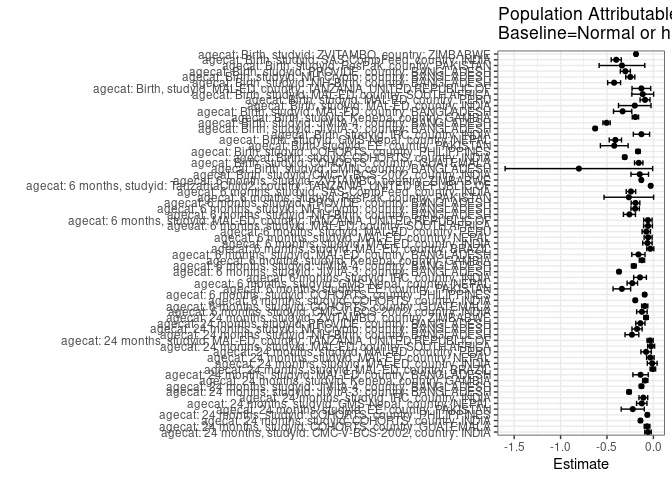

## Results Table

### Parameter: TSM

| agecat | studyid | country | intervention_level | baseline_level | estimate | ci_lower | ci_upper |
| --- | --- | --- | --- | --- | --- | --- | --- |
| Birth | CMC-V-BCS-2002 | INDIA | Normal or high birthweight | NA | -0.8146702 | -1.0384721 | -0.5908682 |
| Birth | CMC-V-BCS-2002 | INDIA | Low birthweight | NA | -2.0777700 | -2.4347127 | -1.7208274 |
| Birth | CMIN | BANGLADESH | Normal or high birthweight | NA | -1.0787109 | -1.9425221 | -0.2148996 |
| Birth | CMIN | BANGLADESH | Low birthweight | NA | -2.6272236 | -3.6117592 | -1.6426881 |
| Birth | COHORTS | GUATEMALA | Normal or high birthweight | NA | 0.2798852 | 0.1976512 | 0.3621192 |
| Birth | COHORTS | GUATEMALA | Low birthweight | NA | -1.4139689 | -1.7125788 | -1.1153589 |
| Birth | COHORTS | INDIA | Normal or high birthweight | NA | -0.3611898 | -0.3880192 | -0.3343604 |
| Birth | COHORTS | INDIA | Low birthweight | NA | -1.8628421 | -1.9180021 | -1.8076821 |
| Birth | COHORTS | PHILIPPINES | Normal or high birthweight | NA | -0.0784699 | -0.1142646 | -0.0426752 |
| Birth | COHORTS | PHILIPPINES | Low birthweight | NA | -1.7656597 | -1.9040676 | -1.6272518 |
| Birth | EE | PAKISTAN | Normal or high birthweight | NA | -1.4393750 | -1.6401971 | -1.2385530 |
| Birth | EE | PAKISTAN | Low birthweight | NA | -2.7183865 | -3.0515806 | -2.3851924 |
| Birth | GMS-Nepal | NEPAL | Normal or high birthweight | NA | -0.6756671 | -0.7542007 | -0.5971336 |
| Birth | GMS-Nepal | NEPAL | Low birthweight | NA | -1.9685034 | -2.0934584 | -1.8435483 |
| Birth | IRC | INDIA | Normal or high birthweight | NA | -0.1813138 | -0.3491141 | -0.0135135 |
| Birth | IRC | INDIA | Low birthweight | NA | -1.0810817 | -1.5400934 | -0.6220699 |
| Birth | JiVitA-3 | BANGLADESH | Normal or high birthweight | NA | -0.9617897 | -0.9791713 | -0.9444080 |
| Birth | JiVitA-3 | BANGLADESH | Low birthweight | NA | -2.4310404 | -2.4535389 | -2.4085420 |
| Birth | JiVitA-4 | BANGLADESH | Normal or high birthweight | NA | -1.0189015 | -1.0671750 | -0.9706280 |
| Birth | JiVitA-4 | BANGLADESH | Low birthweight | NA | -2.4067300 | -2.4681873 | -2.3452726 |
| Birth | Keneba | GAMBIA | Normal or high birthweight | NA | 0.2207298 | 0.1563943 | 0.2850654 |
| Birth | Keneba | GAMBIA | Low birthweight | NA | -1.0878135 | -1.2394510 | -0.9361760 |
| Birth | MAL-ED | BANGLADESH | Normal or high birthweight | NA | -0.7868680 | -0.9126192 | -0.6611167 |
| Birth | MAL-ED | BANGLADESH | Low birthweight | NA | -2.2168488 | -2.4532425 | -1.9804550 |
| Birth | MAL-ED | INDIA | Normal or high birthweight | NA | -1.0030769 | -1.2939170 | -0.7122369 |
| Birth | MAL-ED | INDIA | Low birthweight | NA | -2.1812500 | -2.8210203 | -1.5414797 |
| Birth | MAL-ED | PERU | Normal or high birthweight | NA | -0.7932131 | -0.9043047 | -0.6821215 |
| Birth | MAL-ED | PERU | Low birthweight | NA | -2.6245411 | -3.0486470 | -2.2004351 |
| Birth | MAL-ED | SOUTH AFRICA | Normal or high birthweight | NA | -0.5171304 | -0.6817030 | -0.3525578 |
| Birth | MAL-ED | SOUTH AFRICA | Low birthweight | NA | -2.2787500 | -3.6302840 | -0.9272160 |

[output cut: 104 more lines]

### Parameter: E(Y)

| agecat | studyid | country | intervention_level | baseline_level | estimate | ci_lower | ci_upper |
| --- | --- | --- | --- | --- | --- | --- | --- |
| Birth | CMC-V-BCS-2002 | INDIA | NA | NA | -0.9611957 | -1.1776967 | -0.7446946 |
| Birth | CMIN | BANGLADESH | NA | NA | -1.8811538 | -2.5124807 | -1.2498270 |
| Birth | COHORTS | GUATEMALA | NA | NA | 0.1221939 | 0.0348987 | 0.2094890 |
| Birth | COHORTS | INDIA | NA | NA | -0.6698147 | -0.6979800 | -0.6416494 |
| Birth | COHORTS | PHILIPPINES | NA | NA | -0.2435386 | -0.2827491 | -0.2043282 |
| Birth | EE | PAKISTAN | NA | NA | -1.8608750 | -2.0482045 | -1.6735455 |
| Birth | GMS-Nepal | NEPAL | NA | NA | -1.0851580 | -1.1651811 | -1.0051350 |
| Birth | IRC | INDIA | NA | NA | -0.3096345 | -0.4709405 | -0.1483285 |
| Birth | JiVitA-3 | BANGLADESH | NA | NA | -1.5893720 | -1.6085904 | -1.5701537 |
| Birth | JiVitA-4 | BANGLADESH | NA | NA | -1.5232908 | -1.5723277 | -1.4742539 |
| Birth | Keneba | GAMBIA | NA | NA | 0.0272662 | -0.0366578 | 0.0911901 |
| Birth | MAL-ED | BANGLADESH | NA | NA | -1.1180952 | -1.2525408 | -0.9836496 |
| Birth | MAL-ED | INDIA | NA | NA | -1.2036170 | -1.4976814 | -0.9095527 |
| Birth | MAL-ED | PERU | NA | NA | -0.8827897 | -1.0001058 | -0.7654736 |
| Birth | MAL-ED | SOUTH AFRICA | NA | NA | -0.6317073 | -0.8249555 | -0.4384591 |
| Birth | MAL-ED | TANZANIA, UNITED REPUBLIC OF | NA | NA | -1.1556000 | -1.3655361 | -0.9456639 |
| Birth | NIH-Birth | BANGLADESH | NA | NA | -0.9310197 | -1.0197391 | -0.8423003 |
| Birth | NIH-Crypto | BANGLADESH | NA | NA | -0.9094945 | -0.9809370 | -0.8380521 |
| Birth | PROVIDE | BANGLADESH | NA | NA | -0.8851020 | -0.9601332 | -0.8100709 |
| Birth | ResPak | PAKISTAN | NA | NA | -0.9800000 | -1.4086438 | -0.5513562 |
| Birth | SAS-CompFeed | INDIA | NA | NA | -1.4314217 | -1.5099245 | -1.3529189 |
| Birth | ZVITAMBO | ZIMBABWE | NA | NA | -0.5009660 | -0.5215391 | -0.4803930 |
| 6 months | CMC-V-BCS-2002 | INDIA | NA | NA | -1.4167959 | -1.5608725 | -1.2727194 |
| 6 months | COHORTS | GUATEMALA | NA | NA | -1.7858495 | -1.8598889 | -1.7118102 |
| 6 months | COHORTS | INDIA | NA | NA | -0.9939850 | -1.0230017 | -0.9649683 |
| 6 months | COHORTS | PHILIPPINES | NA | NA | -1.1372543 | -1.1796249 | -1.0948837 |
| 6 months | EE | PAKISTAN | NA | NA | -2.0800314 | -2.1993502 | -1.9607126 |
| 6 months | GMS-Nepal | NEPAL | NA | NA | -1.3510539 | -1.4294158 | -1.2726919 |
| 6 months | IRC | INDIA | NA | NA | -1.2148213 | -1.3469493 | -1.0826933 |
| 6 months | JiVitA-3 | BANGLADESH | NA | NA | -1.3327473 | -1.3568007 | -1.3086940 |
| 6 months | JiVitA-4 | BANGLADESH | NA | NA | -1.3509354 | -1.3927945 | -1.3090764 |
| 6 months | Keneba | GAMBIA | NA | NA | -0.9022065 | -0.9593933 | -0.8450196 |
| 6 months | MAL-ED | BANGLADESH | NA | NA | -1.2094328 | -1.3276892 | -1.0911764 |
| 6 months | MAL-ED | BRAZIL | NA | NA | 0.0475758 | -0.0963508 | 0.1915023 |
| 6 months | MAL-ED | INDIA | NA | NA | -1.1727166 | -1.2902312 | -1.0552020 |
| 6 months | MAL-ED | NEPAL | NA | NA | -0.5397525 | -0.6522623 | -0.4272428 |
| 6 months | MAL-ED | PERU | NA | NA | -1.3083549 | -1.4159952 | -1.2007147 |
| 6 months | MAL-ED | SOUTH AFRICA | NA | NA | -1.0619697 | -1.1900452 | -0.9338942 |
| 6 months | MAL-ED | TANZANIA, UNITED REPUBLIC OF | NA | NA | -1.3098656 | -1.4501587 | -1.1695725 |
| 6 months | NIH-Birth | BANGLADESH | NA | NA | -1.4092745 | -1.5003907 | -1.3181582 |
| 6 months | NIH-Crypto | BANGLADESH | NA | NA | -1.1986783 | -1.2700937 | -1.1272630 |
| 6 months | PROVIDE | BANGLADESH | NA | NA | -1.0916915 | -1.1661176 | -1.0172654 |
| 6 months | ResPak | PAKISTAN | NA | NA | -1.7077451 | -2.2839081 | -1.1315821 |
| 6 months | SAS-CompFeed | INDIA | NA | NA | -1.4032504 | -1.4822018 | -1.3242989 |
| 6 months | TanzaniaChild2 | TANZANIA, UNITED REPUBLIC OF | NA | NA | -0.5394360 | -0.5886359 | -0.4902361 |
| 6 months | ZVITAMBO | ZIMBABWE | NA | NA | -0.8663392 | -0.8919231 | -0.8407552 |
| 24 months | CMC-V-BCS-2002 | INDIA | NA | NA | -2.5467080 | -2.6470149 | -2.4464010 |
| 24 months | COHORTS | GUATEMALA | NA | NA | -2.9641538 | -3.0462906 | -2.8820170 |
| 24 months | COHORTS | INDIA | NA | NA | -2.1129333 | -2.1469655 | -2.0789011 |
| 24 months | COHORTS | PHILIPPINES | NA | NA | -2.4107897 | -2.4561358 | -2.3654436 |
| 24 months | EE | PAKISTAN | NA | NA | -2.6699900 | -2.8138051 | -2.5261749 |
| 24 months | GMS-Nepal | NEPAL | NA | NA | -1.8864887 | -1.9720856 | -1.8008918 |
| 24 months | IRC | INDIA | NA | NA | -1.7814309 | -1.8749526 | -1.6879093 |
| 24 months | JiVitA-3 | BANGLADESH | NA | NA | -2.0396606 | -2.0692906 | -2.0100306 |
| 24 months | JiVitA-4 | BANGLADESH | NA | NA | -1.7744364 | -1.8128124 | -1.7360604 |
| 24 months | Keneba | GAMBIA | NA | NA | -1.5547363 | -1.6172161 | -1.4922564 |
| 24 months | MAL-ED | BANGLADESH | NA | NA | -1.9799762 | -2.1065965 | -1.8533558 |
| 24 months | MAL-ED | BRAZIL | NA | NA | 0.0061144 | -0.1625850 | 0.1748138 |
| 24 months | MAL-ED | INDIA | NA | NA | -1.8550459 | -1.9795611 | -1.7305306 |
| 24 months | MAL-ED | NEPAL | NA | NA | -1.2841403 | -1.4044291 | -1.1638514 |
| 24 months | MAL-ED | PERU | NA | NA | -1.7484757 | -1.8697456 | -1.6272058 |
| 24 months | MAL-ED | SOUTH AFRICA | NA | NA | -1.6471273 | -1.7822999 | -1.5119547 |
| 24 months | MAL-ED | TANZANIA, UNITED REPUBLIC OF | NA | NA | -2.5512346 | -2.7029497 | -2.3995194 |
| 24 months | NIH-Birth | BANGLADESH | NA | NA | -2.2268619 | -2.3322626 | -2.1214612 |
| 24 months | NIH-Crypto | BANGLADESH | NA | NA | -1.4412646 | -1.5249156 | -1.3576135 |
| 24 months | PROVIDE | BANGLADESH | NA | NA | -1.6024221 | -1.6857420 | -1.5191023 |
| 24 months | ZVITAMBO | ZIMBABWE | NA | NA | -1.6024251 | -1.6594303 | -1.5454198 |

### Parameter: ATE

| agecat | studyid | country | intervention_level | baseline_level | estimate | ci_lower | ci_upper |
| --- | --- | --- | --- | --- | --- | --- | --- |
| Birth | CMC-V-BCS-2002 | INDIA | Normal or high birthweight | Normal or high birthweight | 0.0000000 | 0.0000000 | 0.0000000 |
| Birth | CMC-V-BCS-2002 | INDIA | Low birthweight | Normal or high birthweight | -1.2630999 | -1.6854584 | -0.8407413 |
| Birth | CMIN | BANGLADESH | Normal or high birthweight | Normal or high birthweight | 0.0000000 | 0.0000000 | 0.0000000 |
| Birth | CMIN | BANGLADESH | Low birthweight | Normal or high birthweight | -1.5485128 | -2.8533641 | -0.2436615 |
| Birth | COHORTS | GUATEMALA | Normal or high birthweight | Normal or high birthweight | 0.0000000 | 0.0000000 | 0.0000000 |
| Birth | COHORTS | GUATEMALA | Low birthweight | Normal or high birthweight | -1.6938541 | -2.0033905 | -1.3843177 |
| Birth | COHORTS | INDIA | Normal or high birthweight | Normal or high birthweight | 0.0000000 | 0.0000000 | 0.0000000 |
| Birth | COHORTS | INDIA | Low birthweight | Normal or high birthweight | -1.5016523 | -1.5630287 | -1.4402759 |
| Birth | COHORTS | PHILIPPINES | Normal or high birthweight | Normal or high birthweight | 0.0000000 | 0.0000000 | 0.0000000 |
| Birth | COHORTS | PHILIPPINES | Low birthweight | Normal or high birthweight | -1.6871898 | -1.8302035 | -1.5441761 |
| Birth | EE | PAKISTAN | Normal or high birthweight | Normal or high birthweight | 0.0000000 | 0.0000000 | 0.0000000 |
| Birth | EE | PAKISTAN | Low birthweight | Normal or high birthweight | -1.2790115 | -1.6684404 | -0.8895825 |
| Birth | GMS-Nepal | NEPAL | Normal or high birthweight | Normal or high birthweight | 0.0000000 | 0.0000000 | 0.0000000 |
| Birth | GMS-Nepal | NEPAL | Low birthweight | Normal or high birthweight | -1.2928362 | -1.4409078 | -1.1447646 |
| Birth | IRC | INDIA | Normal or high birthweight | Normal or high birthweight | 0.0000000 | 0.0000000 | 0.0000000 |
| Birth | IRC | INDIA | Low birthweight | Normal or high birthweight | -0.8997679 | -1.3899532 | -0.4095826 |
| Birth | JiVitA-3 | BANGLADESH | Normal or high birthweight | Normal or high birthweight | 0.0000000 | 0.0000000 | 0.0000000 |
| Birth | JiVitA-3 | BANGLADESH | Low birthweight | Normal or high birthweight | -1.4692508 | -1.4963116 | -1.4421899 |
| Birth | JiVitA-4 | BANGLADESH | Normal or high birthweight | Normal or high birthweight | 0.0000000 | 0.0000000 | 0.0000000 |
| Birth | JiVitA-4 | BANGLADESH | Low birthweight | Normal or high birthweight | -1.3878285 | -1.4654549 | -1.3102021 |
| Birth | Keneba | GAMBIA | Normal or high birthweight | Normal or high birthweight | 0.0000000 | 0.0000000 | 0.0000000 |
| Birth | Keneba | GAMBIA | Low birthweight | Normal or high birthweight | -1.3085433 | -1.4732935 | -1.1437932 |
| Birth | MAL-ED | BANGLADESH | Normal or high birthweight | Normal or high birthweight | 0.0000000 | 0.0000000 | 0.0000000 |
| Birth | MAL-ED | BANGLADESH | Low birthweight | Normal or high birthweight | -1.4299808 | -1.6984948 | -1.1614668 |
| Birth | MAL-ED | INDIA | Normal or high birthweight | Normal or high birthweight | 0.0000000 | 0.0000000 | 0.0000000 |
| Birth | MAL-ED | INDIA | Low birthweight | Normal or high birthweight | -1.1781731 | -1.8809490 | -0.4753972 |
| Birth | MAL-ED | PERU | Normal or high birthweight | Normal or high birthweight | 0.0000000 | 0.0000000 | 0.0000000 |
| Birth | MAL-ED | PERU | Low birthweight | Normal or high birthweight | -1.8313280 | -2.2698411 | -1.3928149 |
| Birth | MAL-ED | SOUTH AFRICA | Normal or high birthweight | Normal or high birthweight | 0.0000000 | 0.0000000 | 0.0000000 |
| Birth | MAL-ED | SOUTH AFRICA | Low birthweight | Normal or high birthweight | -1.7616196 | -3.1231364 | -0.4001027 |

[output cut: 104 more lines]

### Parameter: PAR

| agecat | studyid | country | intervention_level | baseline_level | estimate | ci_lower | ci_upper |
| --- | --- | --- | --- | --- | --- | --- | --- |
| Birth | CMC-V-BCS-2002 | INDIA | Normal or high birthweight | NA | -0.1465255 | -0.2408799 | -0.0521711 |
| Birth | CMIN | BANGLADESH | Normal or high birthweight | NA | -0.8024430 | -1.5973496 | -0.0075364 |
| Birth | COHORTS | GUATEMALA | Normal or high birthweight | NA | -0.1576913 | -0.2028927 | -0.1124899 |
| Birth | COHORTS | INDIA | Normal or high birthweight | NA | -0.3086249 | -0.3280592 | -0.2891906 |
| Birth | COHORTS | PHILIPPINES | Normal or high birthweight | NA | -0.1650687 | -0.1875733 | -0.1425642 |
| Birth | EE | PAKISTAN | Normal or high birthweight | NA | -0.4215000 | -0.5708968 | -0.2721032 |
| Birth | GMS-Nepal | NEPAL | Normal or high birthweight | NA | -0.4094909 | -0.4754694 | -0.3435124 |
| Birth | IRC | INDIA | Normal or high birthweight | NA | -0.1283207 | -0.2159143 | -0.0407270 |
| Birth | JiVitA-3 | BANGLADESH | Normal or high birthweight | NA | -0.6275824 | -0.6444081 | -0.6107567 |
| Birth | JiVitA-4 | BANGLADESH | Normal or high birthweight | NA | -0.5043894 | -0.5436970 | -0.4650818 |
| Birth | Keneba | GAMBIA | Normal or high birthweight | NA | -0.1934636 | -0.2275778 | -0.1593495 |
| Birth | MAL-ED | BANGLADESH | Normal or high birthweight | NA | -0.3312273 | -0.4296508 | -0.2328037 |
| Birth | MAL-ED | INDIA | Normal or high birthweight | NA | -0.2005401 | -0.3757023 | -0.0253779 |
| Birth | MAL-ED | PERU | Normal or high birthweight | NA | -0.0895766 | -0.1431504 | -0.0360029 |
| Birth | MAL-ED | SOUTH AFRICA | Normal or high birthweight | NA | -0.1145769 | -0.2319816 | 0.0028279 |
| Birth | MAL-ED | TANZANIA, UNITED REPUBLIC OF | Normal or high birthweight | NA | -0.1292441 | -0.2297616 | -0.0287265 |
| Birth | NIH-Birth | BANGLADESH | Normal or high birthweight | NA | -0.4228770 | -0.4924953 | -0.3532587 |
| Birth | NIH-Crypto | BANGLADESH | Normal or high birthweight | NA | -0.2487732 | -0.2977379 | -0.1998085 |
| Birth | PROVIDE | BANGLADESH | Normal or high birthweight | NA | -0.3017100 | -0.3557124 | -0.2477075 |
| Birth | ResPak | PAKISTAN | Normal or high birthweight | NA | -0.3382857 | -0.5842023 | -0.0923692 |
| Birth | SAS-CompFeed | INDIA | Normal or high birthweight | NA | -0.4002001 | -0.4545982 | -0.3458021 |
| Birth | ZVITAMBO | ZIMBABWE | Normal or high birthweight | NA | -0.1870497 | -0.1986798 | -0.1754196 |
| 6 months | CMC-V-BCS-2002 | INDIA | Normal or high birthweight | NA | -0.1232832 | -0.1800009 | -0.0665655 |
| 6 months | COHORTS | GUATEMALA | Normal or high birthweight | NA | -0.0931135 | -0.1263833 | -0.0598436 |
| 6 months | COHORTS | INDIA | Normal or high birthweight | NA | -0.1954348 | -0.2128021 | -0.1780675 |
| 6 months | COHORTS | PHILIPPINES | Normal or high birthweight | NA | -0.0935573 | -0.1112354 | -0.0758792 |
| 6 months | EE | PAKISTAN | Normal or high birthweight | NA | -0.3395779 | -0.4342660 | -0.2448898 |
| 6 months | GMS-Nepal | NEPAL | Normal or high birthweight | NA | -0.2267690 | -0.2828872 | -0.1706508 |
| 6 months | IRC | INDIA | Normal or high birthweight | NA | -0.1438231 | -0.2124957 | -0.0751505 |
| 6 months | JiVitA-3 | BANGLADESH | Normal or high birthweight | NA | -0.3703936 | -0.3874287 | -0.3533585 |
| 6 months | JiVitA-4 | BANGLADESH | Normal or high birthweight | NA | -0.2108436 | -0.2357407 | -0.1859465 |
| 6 months | Keneba | GAMBIA | Normal or high birthweight | NA | -0.1230200 | -0.1512358 | -0.0948043 |
| 6 months | MAL-ED | BANGLADESH | Normal or high birthweight | NA | -0.1609506 | -0.2322881 | -0.0896130 |
| 6 months | MAL-ED | BRAZIL | Normal or high birthweight | NA | -0.0331305 | -0.0712229 | 0.0049618 |
| 6 months | MAL-ED | INDIA | Normal or high birthweight | NA | -0.0639236 | -0.1144839 | -0.0133633 |
| 6 months | MAL-ED | NEPAL | Normal or high birthweight | NA | -0.0563945 | -0.0995878 | -0.0132012 |
| 6 months | MAL-ED | PERU | Normal or high birthweight | NA | -0.0766698 | -0.1215674 | -0.0317721 |
| 6 months | MAL-ED | SOUTH AFRICA | Normal or high birthweight | NA | -0.0578256 | -0.1052633 | -0.0103879 |
| 6 months | MAL-ED | TANZANIA, UNITED REPUBLIC OF | Normal or high birthweight | NA | -0.0587451 | -0.1039785 | -0.0135116 |
| 6 months | NIH-Birth | BANGLADESH | Normal or high birthweight | NA | -0.2579320 | -0.3228052 | -0.1930588 |
| 6 months | NIH-Crypto | BANGLADESH | Normal or high birthweight | NA | -0.1962848 | -0.2415110 | -0.1510586 |
| 6 months | PROVIDE | BANGLADESH | Normal or high birthweight | NA | -0.1924648 | -0.2390891 | -0.1458404 |
| 6 months | ResPak | PAKISTAN | Normal or high birthweight | NA | -0.2643543 | -0.5313970 | 0.0026884 |
| 6 months | SAS-CompFeed | INDIA | Normal or high birthweight | NA | -0.2416366 | -0.2923461 | -0.1909272 |
| 6 months | TanzaniaChild2 | TANZANIA, UNITED REPUBLIC OF | Normal or high birthweight | NA | -0.0287963 | -0.0403341 | -0.0172585 |
| 6 months | ZVITAMBO | ZIMBABWE | Normal or high birthweight | NA | -0.1296612 | -0.1414534 | -0.1178690 |
| 24 months | CMC-V-BCS-2002 | INDIA | Normal or high birthweight | NA | -0.0580492 | -0.0933777 | -0.0227207 |
| 24 months | COHORTS | GUATEMALA | Normal or high birthweight | NA | -0.0679151 | -0.0983483 | -0.0374819 |
| 24 months | COHORTS | INDIA | Normal or high birthweight | NA | -0.1391684 | -0.1567416 | -0.1215951 |
| 24 months | COHORTS | PHILIPPINES | Normal or high birthweight | NA | -0.0649880 | -0.0814197 | -0.0485562 |
| 24 months | EE | PAKISTAN | Normal or high birthweight | NA | -0.2221500 | -0.3465777 | -0.0977223 |
| 24 months | GMS-Nepal | NEPAL | Normal or high birthweight | NA | -0.1249179 | -0.1809279 | -0.0689080 |
| 24 months | IRC | INDIA | Normal or high birthweight | NA | -0.1081094 | -0.1554079 | -0.0608109 |
| 24 months | JiVitA-3 | BANGLADESH | Normal or high birthweight | NA | -0.2619658 | -0.2829101 | -0.2410214 |
| 24 months | JiVitA-4 | BANGLADESH | Normal or high birthweight | NA | -0.1284358 | -0.1502322 | -0.1066394 |
| 24 months | Keneba | GAMBIA | Normal or high birthweight | NA | -0.0873569 | -0.1152045 | -0.0595093 |
| 24 months | MAL-ED | BANGLADESH | Normal or high birthweight | NA | -0.1380021 | -0.2206157 | -0.0553885 |
| 24 months | MAL-ED | BRAZIL | Normal or high birthweight | NA | -0.0052728 | -0.0349237 | 0.0243782 |
| 24 months | MAL-ED | INDIA | Normal or high birthweight | NA | -0.0124029 | -0.0650323 | 0.0402264 |
| 24 months | MAL-ED | NEPAL | Normal or high birthweight | NA | -0.0325206 | -0.0729554 | 0.0079141 |
| 24 months | MAL-ED | PERU | Normal or high birthweight | NA | -0.0785073 | -0.1340320 | -0.0229825 |
| 24 months | MAL-ED | SOUTH AFRICA | Normal or high birthweight | NA | -0.0237023 | -0.0609937 | 0.0135891 |
| 24 months | MAL-ED | TANZANIA, UNITED REPUBLIC OF | Normal or high birthweight | NA | -0.0351631 | -0.0682494 | -0.0020769 |
| 24 months | NIH-Birth | BANGLADESH | Normal or high birthweight | NA | -0.2308881 | -0.3052032 | -0.1565731 |
| 24 months | NIH-Crypto | BANGLADESH | Normal or high birthweight | NA | -0.1758096 | -0.2305990 | -0.1210201 |
| 24 months | PROVIDE | BANGLADESH | Normal or high birthweight | NA | -0.1398983 | -0.1893995 | -0.0903971 |
| 24 months | ZVITAMBO | ZIMBABWE | Normal or high birthweight | NA | -0.0785560 | -0.1018401 | -0.0552719 |